# Homework #1

Your Name

05 Jan 2017

# An example Knitr/R Markdown document

This is a super simple template to show you how to use knitr and rmarkdown to create a html file with your R code and output. Look at http://rmarkdown.rstudio.com/authoring_basics.html to see how to make lists, tables, italics, bold, etc.

## Problem 1

This is my solution to problem 1: add together 2 numbers. I decided to do $1+1$. It was not very hard.

```r
1+1
```

```
## [1] 2
```

## Problem 2

This question asked me to add together the numbers 1, 2, 3, 4, 5, 6, 7, 8, 9, so $\sum_{i=1}^9 i$. This question was also easy using [Smith et al., Adv Numerics 10:5–12, 2002]

```r
sum(1:9)
```

```
## [1] 45
```

## Problem 3

Use the `lm` function to do a linear regression using the example in `?lm`.

```r
## Annette Dobson (1990) "An Introduction to Generalized Linear Models".
## Page 9: Plant Weight Data.
ctl = c(4.17,5.58,5.18,6.11,4.50,4.61,5.17,4.53,5.33,5.14)
trt = c(4.81,4.17,4.41,3.59,5.87,3.83,6.03,4.89,4.32,4.69)
group = gl(2, 10, 20, labels = c("Ctl","Trt"))
weight = c(ctl, trt)
lm.D9 = lm(weight ~ group)
```

We can use `summary` to get a summary.

```r
summary(lm.D9)
```

```
##
## Call:
## lm(formula = weight ~ group)
##
## Residuals:
##     Min      1Q  Median      3Q     Max
## -1.0710 -0.4938  0.0685  0.2462  1.3690
##
## Coefficients:
##             Estimate Std. Error t value Pr(>|t|)
## (Intercept)   5.0320     0.2202  22.850 9.55e-15 ***
## groupTrt     -0.3710     0.3114  -1.191    0.249
## ---
## Signif. codes:  0 '***' 0.001 '**' 0.01 '*' 0.05 '.' 0.1 ' ' 1
##
## Residual standard error: 0.6964 on 18 degrees of freedom
## Multiple R-squared:  0.07308,    Adjusted R-squared:  0.02158
## F-statistic: 1.419 on 1 and 18 DF,  p-value: 0.249
```

## Problem 4

Use `plot()` to get a summary plot.

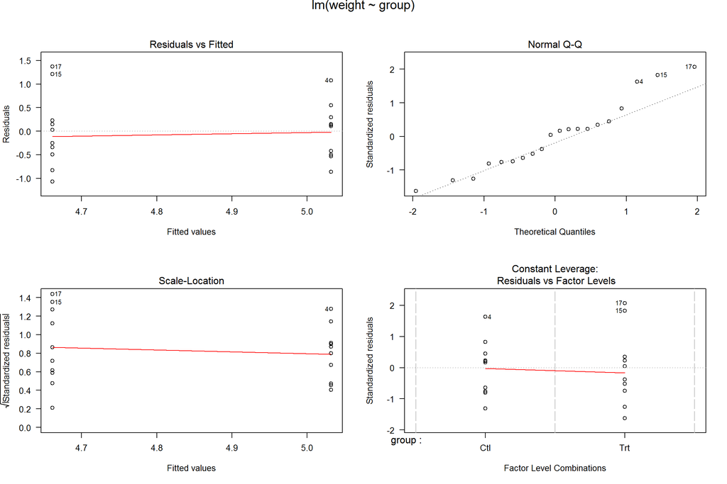

```r
opar <- par(mfrow = c(2,2), oma = c(0, 0, 1.1, 0))
plot(lm.D9, las = 1)      # Residuals, Fitted, ...
```

```r
par(opar)
```

## Problem 5

This problem asked me to write a function to do $\sqrt{b^2 - 4ac}$.

```r
myfun = function(a,b,c){return(sqrt(b^2-4*a*c))}
myfun(1,3,1)
```

```
## [1] 2.236068
```

## Problem 6

This problem asked me to write out a matrix equation $\mathbf{A}\mathbf{B}$ with $\mathbf{A}$ as a $3 \times 2$ matrix and $\mathbf{B}$ as a $2 \times 2$ matrix. I chose this equation: $\mathbf{A}\mathbf{B}= \begin{bmatrix} 1 & 4\\ 2 & 5 \\ 3 & 6\end{bmatrix} \begin{bmatrix} 3 & 0 \\ 0 & 3 \end{bmatrix}$ Here’s my R code:

```r
A=matrix(1:6,3,2)
B=diag(3,2)
A%*%B
```

```
##      [,1] [,2]
## [1,]    3   12
## [2,]    6   15
## [3,]    9   18
```